# 반도체 vs 디스플레이 — 2026년 3분기 실적으로 본 업황 비교

Alpha Hunter Sector Journal | 디스플레이는 바닥을 지나 회복 중, 반도체는 이익 규모가 디스플레이의 수십 배

저자

Alpha Hunter

공개

2026년 11월 1일

> 이 프로젝트는 가상 투자 시뮬레이션 목적으로 작성되었습니다. 실제 투자 권유가 아닙니다.

## 1 핵심 요약

1. **디스플레이 쪽은 2026년 3분기에 회복이 확인됐다.** 삼성디스플레이(SDC)는 매출 8.0조 원, 영업이익 1.1조 원으로 2026년 1분기 바닥 이후 두 분기 연속 올랐다. 영업이익률은 14%다.
2. **LG디스플레이는 3분기 영업이익이 전년보다 줄었다.** 증권사 리포트 기준 3분기 영업이익은 3,253억 원으로 전년 대비 24.5% 감소했다. 목표주가도 1.7만 원에서 1.2만 원으로 낮아졌다.
3. **SDC와 LG디스플레이의 방향이 갈렸다.** SDC는 2025년 4분기가 고점이었고 이후 회복 중이다. LG디스플레이는 3분기에도 전년보다 낮다. 같은 업종 안에서도 회복 속도 차이가 크다.
4. **반도체는 이익 규모와 이익률 모두 디스플레이보다 훨씬 크다.** 삼성전자 DS 부문 3분기 영업이익은 106.5조 원으로 SDC의 약 97배다. SK하이닉스 영업이익은 83.3조 원이고, 회사 발표 영업이익률은 80%다. 두 회사 수치는 모두 회사 공식 보도자료에서 확인했다.

## 2 1. 비교 프레임

| 항목 | 디스플레이 (SDC) | 디스플레이 (LG디스플레이) | 반도체 (삼성전자 DS · SK하이닉스) |
| --- | --- | --- | --- |
| 3분기 매출 | 8.0조 원 (IR 검증) | 미확인 | 삼성전자 DS 147.1조 원 · SK하이닉스 104.6조 원 (회사 발표) |
| 3분기 영업이익 | 1.1조 원 (IR 검증) | 3,253억 원 (증권사 리포트) | 삼성전자 DS 106.5조 원 · SK하이닉스 83.3조 원 (회사 발표) |
| 전년 동기 대비 영업이익 | 2025년 3Q 1.2조 원 대비 감소 | −24.5% (증권사 리포트) | SK하이닉스 +632.1% (회사 발표) · 삼성전자 DS는 발표문에 없어 미확인 |
| 영업이익률 | 14% (IR 공식) | 미확인 | SK하이닉스 80% (회사 표기, 영업이익÷매출은 79.7%) · 삼성전자 DS는 발표문에 없음 |
| 목표주가 변화 | 미확인 | 1.7만 → 1.2만 원 (증권사 리포트) | 미확인 (증권사 리포트 원문 미대조) |

표에서 “IR 검증”과 “회사 발표”는 회사 공식 자료에서 직접 확인한 값이다. “증권사 리포트”는 리포트에 적힌 값을 옮긴 것이라 회사 원자료로는 아직 확인하지 않았다. “미확인”은 근거 없이 채우지 않았다는 뜻이다.

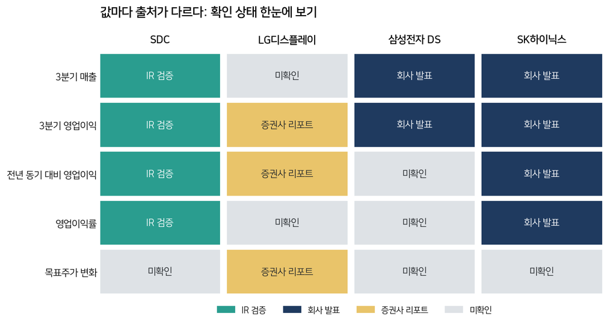

값별 확인 상태: 어떤 칸이 회사 자료로 확인됐고 어떤 칸이 비어 있는지 한눈에 보여준다

## 3 2. 디스플레이 — 삼성디스플레이 7분기 추이

| 분기 | 매출 (조 원) | 영업이익 (조 원) | 영업이익률 (IR 공식) |
| --- | --- | --- | --- |
| 2025년 1Q | 5.9 | 0.5 | — |
| 2025년 2Q | 6.4 | 0.5 | — |
| 2025년 3Q | 8.1 | 1.2 | — |
| 2025년 4Q | 9.5 | 2.0 | — |
| 2026년 1Q | 6.7 | 0.4 | 5% |
| 2026년 2Q | 7.5 | 0.7 | 9% |
| 2026년 3Q | 8.0 | 1.1 | 14% |

근거는 삼성전자 IR 경영설명회 자료의 SDC 페이지다. 2026년 1·2·3분기 자료를 대조해 7개 분기 수치가 모두 맞는 것을 확인했다. 3분기 8.0조 원과 1.1조 원은 삼성전자 3분기 뉴스룸 발표의 디스플레이 부문 수치와도 일치한다. 자세한 분기별 표는 SDC 분기 저널에 있다.

이 흐름을 보면 SDC는 2026년 1분기를 저점으로 삼고 있다. 매출은 6.7조 → 7.5조 → 8.0조 원으로 두 분기 연속 늘었다. 영업이익률은 5%에서 14%로 올라갔고, 영업이익 증가가 매출 증가보다 훨씬 빠르다. 다만 2025년 4분기 영업이익 2.0조 원과 비교하면 3분기 1.1조 원은 55% 수준이다.

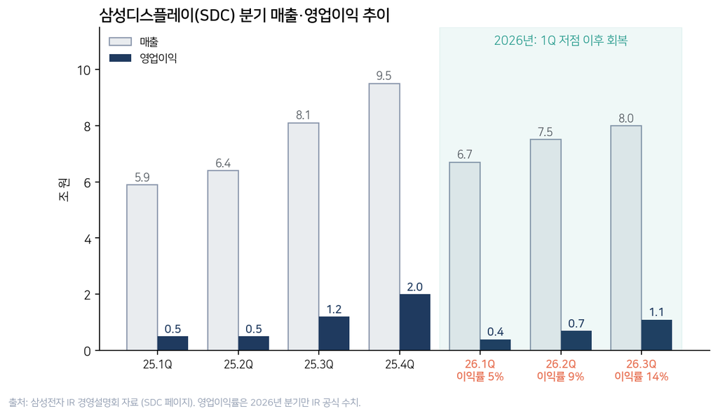

SDC 분기 매출과 영업이익 (2025년 1Q~2026년 3Q). 2026년 분기 아래에 영업이익률을 함께 적었다

## 4 3. 디스플레이 — LG디스플레이 3분기

증권사 리포트 기준 수치다.

- 3분기 영업이익 3,253억 원, 전년 대비 24.5% 감소
- 목표주가 1.7만 원 → 1.2만 원 (약 29% 하향)

전년 대비 감소율로 역산하면 2025년 3분기 영업이익은 약 4,300억 원 수준이다. 역산 값이라 원자료 확인 후 다시 맞춰야 한다. LG디스플레이의 3분기 매출과 영업이익률은 아직 확인하지 않았다. 이 값을 확인하기 전에는 SDC와 매출 규모로 직접 비교하지 않는다.

## 5 4. 반도체 쪽 — 공식 발표 수치

삼성전자와 SK하이닉스의 3분기 실적은 회사 공식 보도자료에서 확인했다.

- **삼성전자 (연결)**: 매출 195.3조 원, 영업이익 107.4조 원. 2분기 대비 매출 23.8조 원, 영업이익 17.9조 원 늘었다. 글로벌 테크 기업 중 처음으로 분기 영업이익 100조 원을 넘었다.
- **삼성전자 DS 부문 (반도체)**: 매출 147.1조 원, 영업이익 106.5조 원. 역대 최대 분기 실적이다. HBM4 판매 확대와 서버용 수요 대응이 원인으로 제시됐다.
- **삼성전자 DX 부문**: 매출 52.1조 원, 영업이익 −0.8조 원으로 적자다. 모바일과 가전 부진이 원인으로 제시됐다.
- **SK하이닉스 (연결, K-IFRS)**: 매출 104.6조 원, 영업이익 83.3조 원, 영업이익률 80%다. 회사 표기는 80%이고 영업이익을 매출로 나누면 79.7%가 나온다. 2분기 대비 매출은 32%, 영업이익은 38% 늘었다. 전년 동기 대비 영업이익은 632.1% 늘었다.

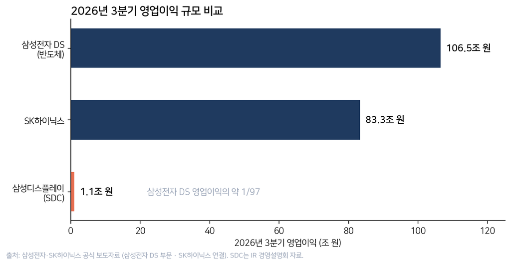

2026년 3분기 영업이익 규모 비교. 삼성전자 DS 영업이익은 SDC의 약 97배다

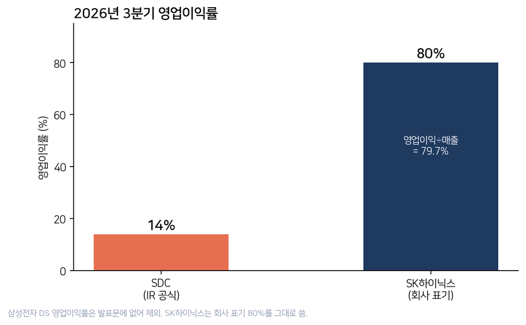

2026년 3분기 영업이익률. SK하이닉스 80%는 회사 표기이고, 영업이익÷매출로 다시 계산하면 79.7%다

삼성전자 DS 부문의 전년 동기 대비 영업이익과 영업이익률은 발표문에 없어서 미확인으로 남겼다. 증권사 목표주가 변화도 리포트 원문을 대조하지 않아 미확인이다.

## 6 5. 해석

**디스플레이는 회복기에 들어섰다고 볼 수 있다.** SDC가 근거다. 영업이익률 14%는 2026년 1분기 5%보다 훨씬 높다. 다만 SDC 하나만으로 업종 전체의 회복이라고 말하기는 어렵다.

**LG디스플레이는 아직 회복이 확인되지 않았다.** 3분기 영업이익이 전년보다 24.5% 줄었고 목표주가도 내려갔다. 같은 디스플레이 업종에서 SDC와 방향이 다르다는 점이 이 보고서의 핵심 관찰이다.

**반도체와 디스플레이는 이익 규모가 다른 단계에 있다.** 삼성전자 DS 영업이익은 SDC의 약 97배다. SK하이닉스 영업이익률 80%는 SDC 14%의 다섯 배 이상이다. 같은 분기에 이익이 어디로 몰렸는지가 숫자로 분명하게 드러난다.

**그래도 “디스플레이가 반도체보다 나은가”라는 질문에는 이 수치만으로 답하지 않는다.** 이익 규모와 이익률 모두 반도체가 앞선다. 다만 SDC 한 회사와 삼성전자 DS 부문 전체를 붙인 비교라 기준이 같지 않다. DS 부문에는 메모리, 파운드리, 시스템LSI가 섞여 있다. 그래서 이 보고서는 두 업종을 순위로 매기기보다 회복의 방향과 속도로 읽는다.

## 7 6. 확인해야 할 점

- LG디스플레이 3분기 매출·영업이익률: 회사 IR 원자료로 확인 필요
- 증권사 리포트 수치(3,253억 원, 1.2만 원): 원문과 대조 필요
- 삼성전자 DS 부문 전년 동기 대비 영업이익·영업이익률: 발표문에 없어 IR 경영설명회 자료로 확인 필요
- 반도체 기업 목표주가 변화: 증권사 리포트 원문 필요

이 프로젝트는 가상 투자 시뮬레이션 목적으로 작성되었습니다. 실제 투자 권유가 아닙니다.